# Лаборатрная рабта №1

Козлова Нонна

Российский университет дружбы народов, Москва, Россия

17 февраля 2023

# Информация

## Докладчик

- Козлова Нонна Юрьевна
- студентка группы НБИбд-04-22
- Российский университет дружбы народов

# Вводная часть

## Актуальность

Лабораторная работа актуальна для тех, кто желаем освоить GitHub.

## Цели и задачи

- Изучить идеологию и применение средств контроля версий.
- Освоить умения по работе с git.

## Материалы и методы

- Процессор `pandoc` для входного формата Markdown
- Результирующие форматы
  - `pdf`
  - `html`
- Автоматизация процесса создания: `Makefile`

# Создание презентации

## Процессор `pandoc`

- Pandoc: преобразователь текстовых файлов
- Сайт: https://pandoc.org/
- Репозиторий: https://github.com/jgm/pandoc

## Формат `pdf`

- Использование LaTeX
- Пакет для презентации: beamer
- Тема оформления: `metropolis`

## Код для формата `pdf`

```yaml
slide_level: 2
aspectratio: 169
section-titles: true
theme: metropolis
```

## Формат `html`

- Используется фреймворк [reveal.js](https://revealjs.com/)
- Используется [тема](https://revealjs.com/themes/) `beige`

## Код для формата `html`

- Тема задаётся в файле `Makefile`

```
REVEALJS_THEME = beige
```

# Результаты

## Получающиеся форматы

- Полученный `pdf`-файл можно демонстрировать в любой программе просмотра `pdf`
- Полученный `html`-файл содержит в себе все ресурсы: изображения, css, скрипты .

## Содержание исследования

1. Базовая настройка git. (рис. [-@fig:001])

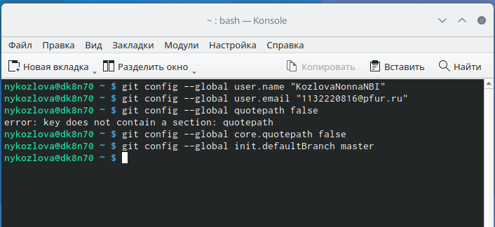

Настраиваем с помощью нужных команд

2. Создаем ключи SSH. (рис. [-@fig:002])

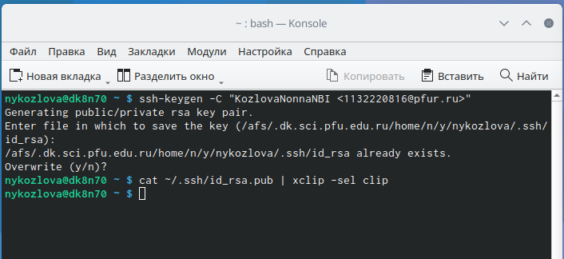

Генерируем ключ через команду ssh-keygen

3. Создаем ключ PGP. (рис. [-@fig:003])

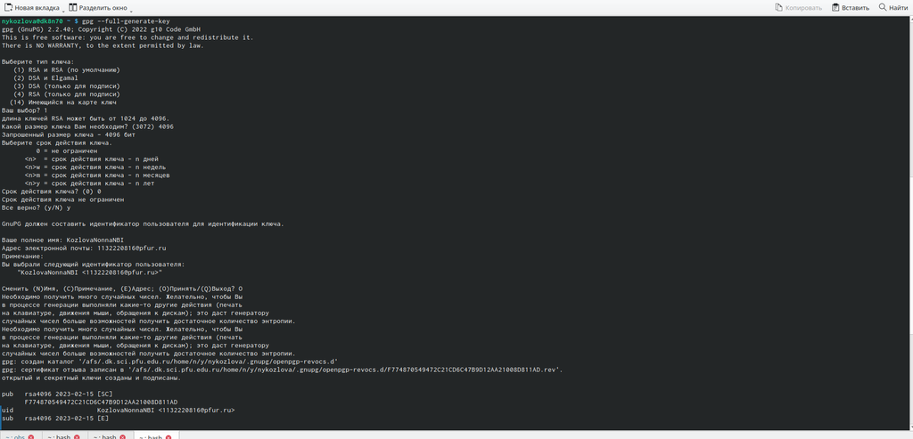

Отвечаем на все вопросы по заданным ответам

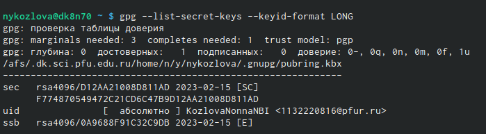

Пользуемся данными командами

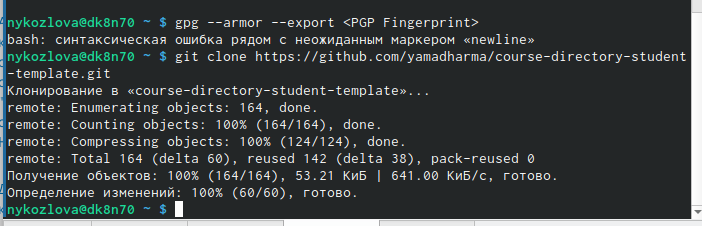

Пользуемся командой git clone

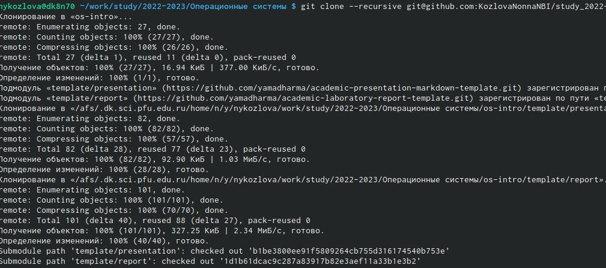

Пользуемся командой git clone

7. Настраиваем каталог курса. (рис. [-@fig:007])

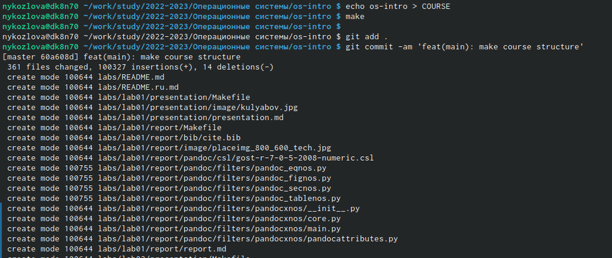

Пользуемся командами git

8. Отправляем файлы на сервер. (рис. [-@fig:008])

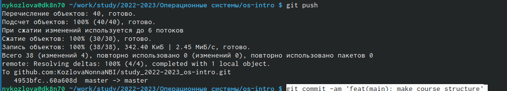

Пользуемся командой git push

9. Проверяем работу. (рис. [-@fig:009])

[figure not shown]

Заходим на сайт GitHub

## Результаты

- Настроили GitHub
- Создали ключи

## Итоговый слайд

- В ходе выполнения лабораторной работы, мы изучили идеологию и применение средств контроля версий и освоили умения работать с git.